# Vinho Verde Wines:

# Multivariate Analysis

In the bivariate analysis, I found a relationship between quality and both alcohol and RS. Looking at alcohol, residual sugar, and quality together shows the link between higher alcohol and quality is strongest in the middle ranges of residual sugar. Mean quality rating is highest in the mid-sugar/high alcohol region. There may be an area of higher quality also in the lowest alcohol/highest sugar decile. When grouped by decile of alcohol and RS, the largest number of wines are in the mid-sugar/high alcohol and high-sugar/low alcohol areas. This is perhaps not surprising, as quality ratings seem higher in these regions so winemakers might target these ranges in an effort to make a better product.

# Final Plots and Summary

## Plot One: Quality Ratings Distribution:

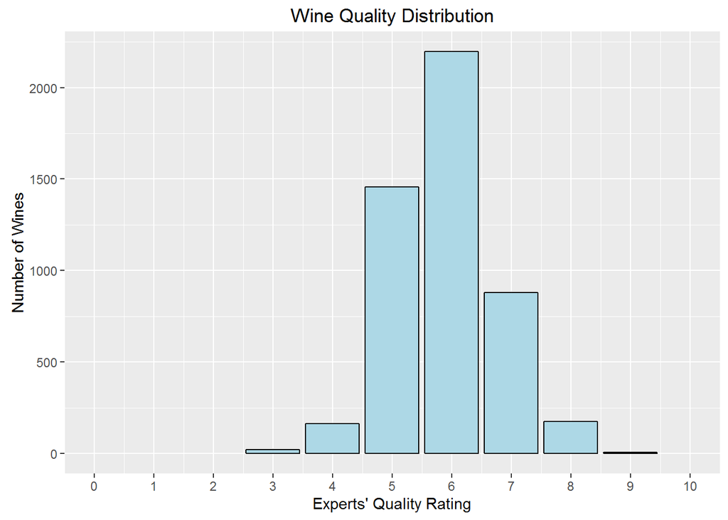

The distribution of quality ratings shows no wines rated at the lowest (0,1,2) or highest (10) ends of the scale. It seems likely that any very poor wines didn’t make it to market, or into the pool of wines judged for this dataset. It’s not as clear why there should be no “very excellent” wines, out of almost 5,000 judged. Perhaps this type of wine, meant to be consumed young with no aging, couldn’t achieve a really superior rating by a wine expert.

## Plot Two: Quality and Residual Sugar:

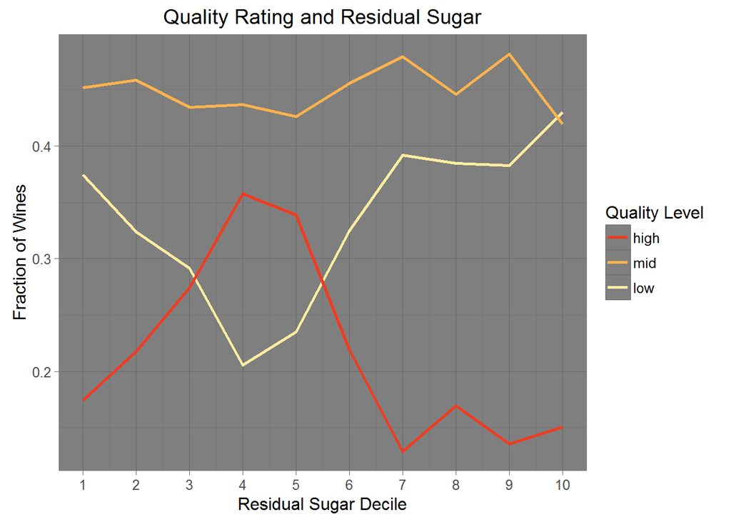

This plot shows that almost half of wines were rated in the middle range of quality at all deciles of residual sugar. There is a region, however, in the 4th-5th deciles of residual sugar where wines were much more likely to receive a high quality score. Further, wines in the higher deciles of residual sugar were very unlikely to receive a high quality rating. At the top decile of RS, the fraction of lower quality wines is even slightly higher than the mid-rated ones.

## Plot Three: Quality, Alcohol, Residual Sugar:

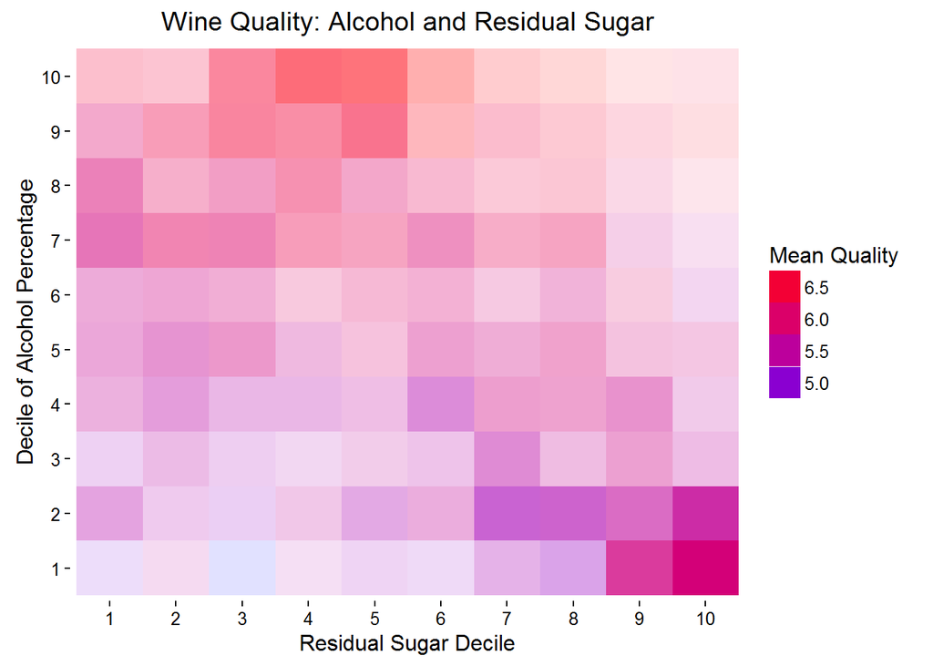

This plot shows the quality rating mean arranged by decile of residual sugar and alcohol. The intensity of the shading corresponds to the number of wines in each group. The highest quality area is in the mid-sugar + high-alcohol range. The high-sugar + low-alcohol region shows a large number of wines of medium quality.

# Reflection

This dataset was challenging in that the major feature of interest, quality rating, showed at best modest correlation with any of the objective input variables. There were definitely patterns of quality related to two important attributes (alcohol and RS). However, I was unable to find a combination of measures which could really discriminate higher from lower quality wines. I did find a few interesting relationships between some of the individual objective measures.  
The variable nature of the wine styles in the dataset may have contributed to the challenges. When examining counts of wines by alcohol and residual sugar deciles, there did appear to be separate regions with higher numbers. Perhaps splitting the dataset into these groups, then analyzing again based on the other objective variables might show additional correlations. One variable which was not present in the dataset was the degree of carbonation. Vinho Verde wines are often mildly sparkling, but many are still as well. The combination of attributes which make an excellent sparkling wine might be different from those in a high-quality still wine. Also, there may well be more sophisticated analysis approaches which could, in fact, create a model for quality prediction from the variables in this dataset.